# Risk Factor Analysis

## Outcome Variable

**Outcome Variable:** co_occurence

## Predictor Variables

**Intervention Variable:** ever_stunted06

**Adjustment Set:**

- sex
- arm
- enstunt
- month
- brthmon
- hhwealth_quart
- W_birthwt
- W_birthlen
- W_mage
- W_mhtcm
- W_meducyrs
- W_feducyrs
- delta_month
- delta_brthmon
- delta_hhwealth_quart
- delta_W_birthwt
- delta_W_birthlen
- delta_W_mage
- delta_W_mhtcm
- delta_W_meducyrs
- delta_W_feducyrs

## Stratifying Variables

The analysis was stratified on these variable(s):

- studyid
- country

## Data Summary

| studyid | country | ever_stunted06 | co_occurence | n_cell | n |
| --- | --- | --- | --- | --- | --- |
| ki0047075b-MAL-ED | BANGLADESH | 0 | 0 | 141 | 221 |
| ki0047075b-MAL-ED | BANGLADESH | 0 | 1 | 5 | 221 |
| ki0047075b-MAL-ED | BANGLADESH | 1 | 0 | 66 | 221 |
| ki0047075b-MAL-ED | BANGLADESH | 1 | 1 | 9 | 221 |
| ki0047075b-MAL-ED | BRAZIL | 0 | 0 | 146 | 180 |
| ki0047075b-MAL-ED | BRAZIL | 0 | 1 | 0 | 180 |
| ki0047075b-MAL-ED | BRAZIL | 1 | 0 | 33 | 180 |
| ki0047075b-MAL-ED | BRAZIL | 1 | 1 | 1 | 180 |
| ki0047075b-MAL-ED | INDIA | 0 | 0 | 139 | 228 |
| ki0047075b-MAL-ED | INDIA | 0 | 1 | 6 | 228 |
| ki0047075b-MAL-ED | INDIA | 1 | 0 | 72 | 228 |
| ki0047075b-MAL-ED | INDIA | 1 | 1 | 11 | 228 |
| ki0047075b-MAL-ED | NEPAL | 0 | 0 | 187 | 229 |
| ki0047075b-MAL-ED | NEPAL | 0 | 1 | 1 | 229 |
| ki0047075b-MAL-ED | NEPAL | 1 | 0 | 38 | 229 |
| ki0047075b-MAL-ED | NEPAL | 1 | 1 | 3 | 229 |
| ki0047075b-MAL-ED | PERU | 0 | 0 | 116 | 222 |
| ki0047075b-MAL-ED | PERU | 0 | 1 | 0 | 222 |
| ki0047075b-MAL-ED | PERU | 1 | 0 | 100 | 222 |
| ki0047075b-MAL-ED | PERU | 1 | 1 | 6 | 222 |
| ki0047075b-MAL-ED | SOUTH AFRICA | 0 | 0 | 141 | 241 |
| ki0047075b-MAL-ED | SOUTH AFRICA | 0 | 1 | 2 | 241 |
| ki0047075b-MAL-ED | SOUTH AFRICA | 1 | 0 | 96 | 241 |
| ki0047075b-MAL-ED | SOUTH AFRICA | 1 | 1 | 2 | 241 |
| ki0047075b-MAL-ED | TANZANIA, UNITED REPUBLIC OF | 0 | 0 | 132 | 225 |
| ki0047075b-MAL-ED | TANZANIA, UNITED REPUBLIC OF | 0 | 1 | 0 | 225 |
| ki0047075b-MAL-ED | TANZANIA, UNITED REPUBLIC OF | 1 | 0 | 92 | 225 |
| ki0047075b-MAL-ED | TANZANIA, UNITED REPUBLIC OF | 1 | 1 | 1 | 225 |
| ki1000108-CMC-V-BCS-2002 | INDIA | 0 | 0 | 171 | 366 |
| ki1000108-CMC-V-BCS-2002 | INDIA | 0 | 1 | 7 | 366 |

[output cut: 90 more lines]

The following strata were considered:

- studyid: ki0047075b-MAL-ED, country: BANGLADESH
- studyid: ki0047075b-MAL-ED, country: BRAZIL
- studyid: ki0047075b-MAL-ED, country: INDIA
- studyid: ki0047075b-MAL-ED, country: NEPAL
- studyid: ki0047075b-MAL-ED, country: PERU
- studyid: ki0047075b-MAL-ED, country: SOUTH AFRICA
- studyid: ki0047075b-MAL-ED, country: TANZANIA, UNITED REPUBLIC OF
- studyid: ki1000108-CMC-V-BCS-2002, country: INDIA
- studyid: ki1000108-IRC, country: INDIA
- studyid: ki1000109-EE, country: PAKISTAN
- studyid: ki1000109-ResPak, country: PAKISTAN
- studyid: ki1000304b-SAS-CompFeed, country: INDIA
- studyid: ki1000304b-SAS-FoodSuppl, country: INDIA
- studyid: ki1017093-NIH-Birth, country: BANGLADESH
- studyid: ki1017093b-PROVIDE, country: BANGLADESH
- studyid: ki1017093c-NIH-Crypto, country: BANGLADESH
- studyid: ki1066203-TanzaniaChild2, country: TANZANIA, UNITED REPUBLIC OF
- studyid: ki1101329-Keneba, country: GAMBIA
- studyid: ki1113344-GMS-Nepal, country: NEPAL
- studyid: ki1114097-CMIN, country: BANGLADESH
- studyid: ki1114097-CMIN, country: BRAZIL
- studyid: ki1114097-CMIN, country: GUINEA-BISSAU
- studyid: ki1114097-CMIN, country: PERU
- studyid: ki1114097-CONTENT, country: PERU
- studyid: ki1119695-PROBIT, country: BELARUS
- studyid: ki1126311-ZVITAMBO, country: ZIMBABWE
- studyid: ki1135781-COHORTS, country: GUATEMALA
- studyid: ki1135781-COHORTS, country: PHILIPPINES
- studyid: ki1148112-LCNI-5, country: MALAWI
- studyid: kiGH5241-JiVitA-4, country: BANGLADESH

### Dropped Strata

Some strata were dropped due to rare outcomes:

- studyid: ki0047075b-MAL-ED, country: BRAZIL
- studyid: ki0047075b-MAL-ED, country: NEPAL
- studyid: ki0047075b-MAL-ED, country: PERU
- studyid: ki0047075b-MAL-ED, country: SOUTH AFRICA
- studyid: ki0047075b-MAL-ED, country: TANZANIA, UNITED REPUBLIC OF
- studyid: ki1000108-IRC, country: INDIA
- studyid: ki1000109-ResPak, country: PAKISTAN
- studyid: ki1066203-TanzaniaChild2, country: TANZANIA, UNITED REPUBLIC OF
- studyid: ki1114097-CMIN, country: BRAZIL
- studyid: ki1114097-CMIN, country: PERU
- studyid: ki1114097-CONTENT, country: PERU
- studyid: ki1119695-PROBIT, country: BELARUS
- studyid: ki1148112-LCNI-5, country: MALAWI

## Methods Detail

We’re interested in the causal parameters $E[Y_a]$ for all values of $a \in \mathcal{A}$. These parameters represent the mean outcome if, possibly contrary to fact, we intervened to set all units to have $A=a$. Under the randomization and positivity assumptions, these are identified by the statistical parameters $\psi_a=E_W[E_{Y|A,W}(Y|A=a,W)]$. In addition, we’re interested in the mean of $Y$, $E[Y]$ under no intervention (the observed mean). We will estimate these parameters by using SuperLearner to fit the relevant likelihood factors – $E_{Y|A,W}(Y|A=a,W)$ and $p(A=a|W)$, and then updating our likelihood fit using a joint TMLE.

For unadjusted analyses ($W=\{\}$), initial likelihoods were estimated using Lrnr_glm to estimate the simple $E(Y|A)$ and Lrnr_mean to estimate $p(A)$. For adjusted analyses, a small library containing Lrnr_glmnet, Lrnr_xgboost, and Lrnr_mean was used.

Having estimated these parameters, we will then use the delta method to estimate relative risks and attributable risks relative to a prespecified baseline level of $A$.

# Results Detail

## Results Plots

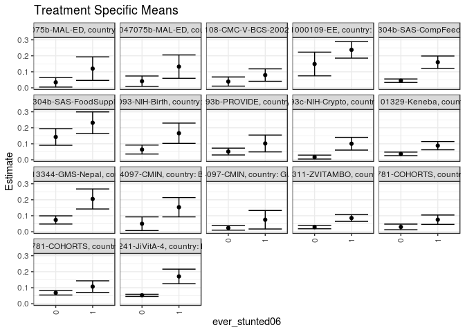

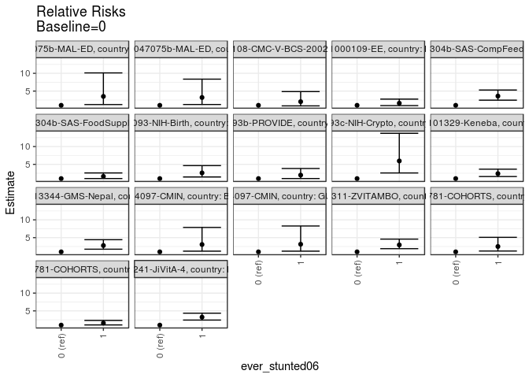

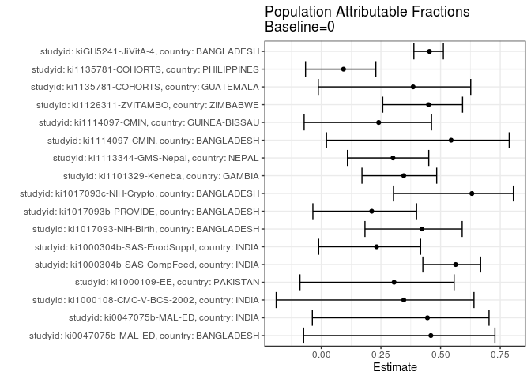

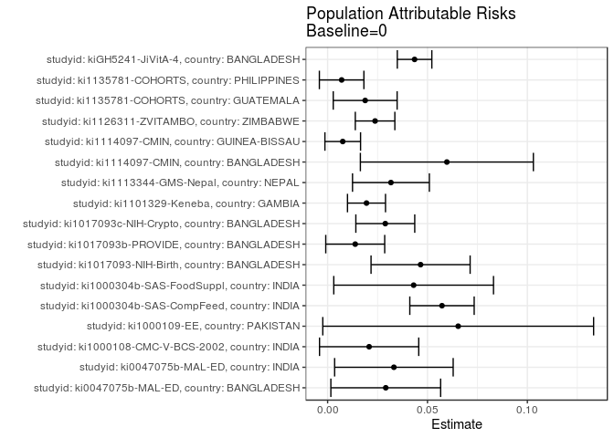

## Results Table

### Parameter: TSM

| studyid | country | intervention_level | baseline_level | estimate | ci_lower | ci_upper |
| --- | --- | --- | --- | --- | --- | --- |
| ki0047075b-MAL-ED | BANGLADESH | 0 | NA | 0.0342466 | 0.0046802 | 0.0638130 |
| ki0047075b-MAL-ED | BANGLADESH | 1 | NA | 0.1200000 | 0.0462887 | 0.1937113 |
| ki0047075b-MAL-ED | INDIA | 0 | NA | 0.0413793 | 0.0088905 | 0.0738681 |
| ki0047075b-MAL-ED | INDIA | 1 | NA | 0.1325301 | 0.0594250 | 0.2056353 |
| ki1000108-CMC-V-BCS-2002 | INDIA | 0 | NA | 0.0393258 | 0.0107329 | 0.0679188 |
| ki1000108-CMC-V-BCS-2002 | INDIA | 1 | NA | 0.0797872 | 0.0410013 | 0.1185732 |
| ki1000109-EE | PAKISTAN | 0 | NA | 0.1489118 | 0.0746995 | 0.2231241 |
| ki1000109-EE | PAKISTAN | 1 | NA | 0.2374001 | 0.1856734 | 0.2891268 |
| ki1000304b-SAS-CompFeed | INDIA | 0 | NA | 0.0444087 | 0.0335432 | 0.0552743 |
| ki1000304b-SAS-CompFeed | INDIA | 1 | NA | 0.1599362 | 0.1210582 | 0.1988142 |
| ki1000304b-SAS-FoodSuppl | INDIA | 0 | NA | 0.1426925 | 0.0906428 | 0.1947423 |
| ki1000304b-SAS-FoodSuppl | INDIA | 1 | NA | 0.2314145 | 0.1633728 | 0.2994563 |
| ki1017093-NIH-Birth | BANGLADESH | 0 | NA | 0.0638468 | 0.0358892 | 0.0918044 |
| ki1017093-NIH-Birth | BANGLADESH | 1 | NA | 0.1659080 | 0.1025412 | 0.2292748 |
| ki1017093b-PROVIDE | BANGLADESH | 0 | NA | 0.0515167 | 0.0301995 | 0.0728339 |
| ki1017093b-PROVIDE | BANGLADESH | 1 | NA | 0.1020020 | 0.0493772 | 0.1546269 |
| ki1017093c-NIH-Crypto | BANGLADESH | 0 | NA | 0.0168675 | 0.0044682 | 0.0292668 |
| ki1017093c-NIH-Crypto | BANGLADESH | 1 | NA | 0.1004566 | 0.0606121 | 0.1403012 |
| ki1101329-Keneba | GAMBIA | 0 | NA | 0.0368459 | 0.0256828 | 0.0480089 |
| ki1101329-Keneba | GAMBIA | 1 | NA | 0.0882678 | 0.0624988 | 0.1140369 |
| ki1113344-GMS-Nepal | NEPAL | 0 | NA | 0.0737548 | 0.0481701 | 0.0993396 |
| ki1113344-GMS-Nepal | NEPAL | 1 | NA | 0.2048451 | 0.1422944 | 0.2673959 |
| ki1114097-CMIN | BANGLADESH | 0 | NA | 0.0500000 | 0.0071932 | 0.0928068 |
| ki1114097-CMIN | BANGLADESH | 1 | NA | 0.1532847 | 0.0928308 | 0.2137385 |
| ki1114097-CMIN | GUINEA-BISSAU | 0 | NA | 0.0238612 | 0.0099167 | 0.0378056 |
| ki1114097-CMIN | GUINEA-BISSAU | 1 | NA | 0.0750000 | 0.0172295 | 0.1327705 |
| ki1126311-ZVITAMBO | ZIMBABWE | 0 | NA | 0.0290654 | 0.0184783 | 0.0396525 |
| ki1126311-ZVITAMBO | ZIMBABWE | 1 | NA | 0.0857647 | 0.0647857 | 0.1067437 |
| ki1135781-COHORTS | GUATEMALA | 0 | NA | 0.0300398 | 0.0122842 | 0.0477954 |
| ki1135781-COHORTS | GUATEMALA | 1 | NA | 0.0753440 | 0.0461306 | 0.1045575 |
| ki1135781-COHORTS | PHILIPPINES | 0 | NA | 0.0681770 | 0.0542560 | 0.0820980 |
| ki1135781-COHORTS | PHILIPPINES | 1 | NA | 0.1070021 | 0.0709399 | 0.1430643 |
| kiGH5241-JiVitA-4 | BANGLADESH | 0 | NA | 0.0524858 | 0.0459627 | 0.0590089 |
| kiGH5241-JiVitA-4 | BANGLADESH | 1 | NA | 0.1704624 | 0.1248841 | 0.2160407 |

### Parameter: E(Y)

| studyid | country | intervention_level | baseline_level | estimate | ci_lower | ci_upper |
| --- | --- | --- | --- | --- | --- | --- |
| ki0047075b-MAL-ED | BANGLADESH | NA | NA | 0.0633484 | 0.0311604 | 0.0955364 |
| ki0047075b-MAL-ED | INDIA | NA | NA | 0.0745614 | 0.0403897 | 0.1087331 |
| ki1000108-CMC-V-BCS-2002 | INDIA | NA | NA | 0.0601093 | 0.0357249 | 0.0844936 |
| ki1000109-EE | PAKISTAN | NA | NA | 0.2142857 | 0.1712366 | 0.2573348 |
| ki1000304b-SAS-CompFeed | INDIA | NA | NA | 0.1016680 | 0.0902317 | 0.1131043 |
| ki1000304b-SAS-FoodSuppl | INDIA | NA | NA | 0.1857585 | 0.1432798 | 0.2282372 |
| ki1017093-NIH-Birth | BANGLADESH | NA | NA | 0.1103896 | 0.0817833 | 0.1389959 |
| ki1017093b-PROVIDE | BANGLADESH | NA | NA | 0.0653358 | 0.0446834 | 0.0859881 |
| ki1017093c-NIH-Crypto | BANGLADESH | NA | NA | 0.0457413 | 0.0294659 | 0.0620168 |
| ki1101329-Keneba | GAMBIA | NA | NA | 0.0563063 | 0.0455826 | 0.0670300 |
| ki1113344-GMS-Nepal | NEPAL | NA | NA | 0.1054545 | 0.0797627 | 0.1311464 |
| ki1114097-CMIN | BANGLADESH | NA | NA | 0.1097046 | 0.0698323 | 0.1495770 |
| ki1114097-CMIN | GUINEA-BISSAU | NA | NA | 0.0314233 | 0.0167088 | 0.0461377 |
| ki1126311-ZVITAMBO | ZIMBABWE | NA | NA | 0.0528211 | 0.0420773 | 0.0635650 |
| ki1135781-COHORTS | GUATEMALA | NA | NA | 0.0488432 | 0.0336878 | 0.0639985 |
| ki1135781-COHORTS | PHILIPPINES | NA | NA | 0.0751910 | 0.0648251 | 0.0855569 |
| kiGH5241-JiVitA-4 | BANGLADESH | NA | NA | 0.0960141 | 0.0859500 | 0.1060782 |

### Parameter: RR

| studyid | country | intervention_level | baseline_level | estimate | ci_lower | ci_upper |
| --- | --- | --- | --- | --- | --- | --- |
| ki0047075b-MAL-ED | BANGLADESH | 0 | 0 | 1.000000 | 1.0000000 | 1.000000 |
| ki0047075b-MAL-ED | BANGLADESH | 1 | 0 | 3.504000 | 1.2145141 | 10.109406 |
| ki0047075b-MAL-ED | INDIA | 0 | 0 | 1.000000 | 1.0000000 | 1.000000 |
| ki0047075b-MAL-ED | INDIA | 1 | 0 | 3.202811 | 1.2268899 | 8.360978 |
| ki1000108-CMC-V-BCS-2002 | INDIA | 0 | 0 | 1.000000 | 1.0000000 | 1.000000 |
| ki1000108-CMC-V-BCS-2002 | INDIA | 1 | 0 | 2.028875 | 0.8460862 | 4.865149 |
| ki1000109-EE | PAKISTAN | 0 | 0 | 1.000000 | 1.0000000 | 1.000000 |
| ki1000109-EE | PAKISTAN | 1 | 0 | 1.594233 | 0.9259771 | 2.744752 |
| ki1000304b-SAS-CompFeed | INDIA | 0 | 0 | 1.000000 | 1.0000000 | 1.000000 |
| ki1000304b-SAS-CompFeed | INDIA | 1 | 0 | 3.601458 | 2.4499681 | 5.294151 |
| ki1000304b-SAS-FoodSuppl | INDIA | 0 | 0 | 1.000000 | 1.0000000 | 1.000000 |
| ki1000304b-SAS-FoodSuppl | INDIA | 1 | 0 | 1.621771 | 1.0154832 | 2.590038 |
| ki1017093-NIH-Birth | BANGLADESH | 0 | 0 | 1.000000 | 1.0000000 | 1.000000 |
| ki1017093-NIH-Birth | BANGLADESH | 1 | 0 | 2.598533 | 1.4525557 | 4.648615 |
| ki1017093b-PROVIDE | BANGLADESH | 0 | 0 | 1.000000 | 1.0000000 | 1.000000 |
| ki1017093b-PROVIDE | BANGLADESH | 1 | 0 | 1.979980 | 1.0222085 | 3.835147 |
| ki1017093c-NIH-Crypto | BANGLADESH | 0 | 0 | 1.000000 | 1.0000000 | 1.000000 |
| ki1017093c-NIH-Crypto | BANGLADESH | 1 | 0 | 5.955642 | 2.5832748 | 13.730507 |
| ki1101329-Keneba | GAMBIA | 0 | 0 | 1.000000 | 1.0000000 | 1.000000 |
| ki1101329-Keneba | GAMBIA | 1 | 0 | 2.395598 | 1.5747943 | 3.644214 |
| ki1113344-GMS-Nepal | NEPAL | 0 | 0 | 1.000000 | 1.0000000 | 1.000000 |
| ki1113344-GMS-Nepal | NEPAL | 1 | 0 | 2.777380 | 1.7457952 | 4.418525 |
| ki1114097-CMIN | BANGLADESH | 0 | 0 | 1.000000 | 1.0000000 | 1.000000 |
| ki1114097-CMIN | BANGLADESH | 1 | 0 | 3.065693 | 1.1944241 | 7.868626 |
| ki1114097-CMIN | GUINEA-BISSAU | 0 | 0 | 1.000000 | 1.0000000 | 1.000000 |
| ki1114097-CMIN | GUINEA-BISSAU | 1 | 0 | 3.143182 | 1.1952586 | 8.265652 |
| ki1126311-ZVITAMBO | ZIMBABWE | 0 | 0 | 1.000000 | 1.0000000 | 1.000000 |
| ki1126311-ZVITAMBO | ZIMBABWE | 1 | 0 | 2.950751 | 1.9018638 | 4.578104 |
| ki1135781-COHORTS | GUATEMALA | 0 | 0 | 1.000000 | 1.0000000 | 1.000000 |
| ki1135781-COHORTS | GUATEMALA | 1 | 0 | 2.508141 | 1.2364641 | 5.087708 |
| ki1135781-COHORTS | PHILIPPINES | 0 | 0 | 1.000000 | 1.0000000 | 1.000000 |
| ki1135781-COHORTS | PHILIPPINES | 1 | 0 | 1.569475 | 1.0594702 | 2.324984 |
| kiGH5241-JiVitA-4 | BANGLADESH | 0 | 0 | 1.000000 | 1.0000000 | 1.000000 |
| kiGH5241-JiVitA-4 | BANGLADESH | 1 | 0 | 3.247784 | 2.4237998 | 4.351885 |

### Parameter: PAR

| studyid | country | intervention_level | baseline_level | estimate | ci_lower | ci_upper |
| --- | --- | --- | --- | --- | --- | --- |
| ki0047075b-MAL-ED | BANGLADESH | 0 | NA | 0.0291018 | 0.0016205 | 0.0565832 |
| ki0047075b-MAL-ED | INDIA | 0 | NA | 0.0331821 | 0.0035059 | 0.0628582 |
| ki1000108-CMC-V-BCS-2002 | INDIA | 0 | NA | 0.0207834 | -0.0040547 | 0.0456216 |
| ki1000109-EE | PAKISTAN | 0 | NA | 0.0653739 | -0.0024227 | 0.1331705 |
| ki1000304b-SAS-CompFeed | INDIA | 0 | NA | 0.0572593 | 0.0411453 | 0.0733732 |
| ki1000304b-SAS-FoodSuppl | INDIA | 0 | NA | 0.0430660 | 0.0030778 | 0.0830542 |
| ki1017093-NIH-Birth | BANGLADESH | 0 | NA | 0.0465428 | 0.0217392 | 0.0713464 |
| ki1017093b-PROVIDE | BANGLADESH | 0 | NA | 0.0138191 | -0.0009373 | 0.0285754 |
| ki1017093c-NIH-Crypto | BANGLADESH | 0 | NA | 0.0288739 | 0.0141307 | 0.0436170 |
| ki1101329-Keneba | GAMBIA | 0 | NA | 0.0194605 | 0.0099440 | 0.0289769 |
| ki1113344-GMS-Nepal | NEPAL | 0 | NA | 0.0316997 | 0.0124623 | 0.0509371 |
| ki1114097-CMIN | BANGLADESH | 0 | NA | 0.0597046 | 0.0163932 | 0.1030160 |
| ki1114097-CMIN | GUINEA-BISSAU | 0 | NA | 0.0075621 | -0.0013584 | 0.0164826 |
| ki1126311-ZVITAMBO | ZIMBABWE | 0 | NA | 0.0237557 | 0.0138546 | 0.0336569 |
| ki1135781-COHORTS | GUATEMALA | 0 | NA | 0.0188034 | 0.0028111 | 0.0347957 |
| ki1135781-COHORTS | PHILIPPINES | 0 | NA | 0.0070140 | -0.0041333 | 0.0181613 |
| kiGH5241-JiVitA-4 | BANGLADESH | 0 | NA | 0.0435283 | 0.0348845 | 0.0521722 |

### Parameter: PAF

| studyid | country | intervention_level | baseline_level | estimate | ci_lower | ci_upper |
| --- | --- | --- | --- | --- | --- | --- |
| ki0047075b-MAL-ED | BANGLADESH | 0 | NA | 0.4593933 | -0.0739341 | 0.7278645 |
| ki0047075b-MAL-ED | INDIA | 0 | NA | 0.4450304 | -0.0374217 | 0.7031186 |
| ki1000108-CMC-V-BCS-2002 | INDIA | 0 | NA | 0.3457610 | -0.1889189 | 0.6399849 |
| ki1000109-EE | PAKISTAN | 0 | NA | 0.3050782 | -0.0893658 | 0.5566996 |
| ki1000304b-SAS-CompFeed | INDIA | 0 | NA | 0.5631984 | 0.4256844 | 0.6677861 |
| ki1000304b-SAS-FoodSuppl | INDIA | 0 | NA | 0.2318386 | -0.0108799 | 0.4162789 |
| ki1017093-NIH-Birth | BANGLADESH | 0 | NA | 0.4216231 | 0.1831543 | 0.5904736 |
| ki1017093b-PROVIDE | BANGLADESH | 0 | NA | 0.2115083 | -0.0351975 | 0.3994197 |
| ki1017093c-NIH-Crypto | BANGLADESH | 0 | NA | 0.6312422 | 0.3025665 | 0.8050247 |
| ki1101329-Keneba | GAMBIA | 0 | NA | 0.3456177 | 0.1705228 | 0.4837516 |
| ki1113344-GMS-Nepal | NEPAL | 0 | NA | 0.3006009 | 0.1097021 | 0.4505669 |
| ki1114097-CMIN | BANGLADESH | 0 | NA | 0.5442308 | 0.0218796 | 0.7876278 |
| ki1114097-CMIN | GUINEA-BISSAU | 0 | NA | 0.2406533 | -0.0718793 | 0.4620594 |
| ki1126311-ZVITAMBO | ZIMBABWE | 0 | NA | 0.4497395 | 0.2575835 | 0.5921607 |
| ki1135781-COHORTS | GUATEMALA | 0 | NA | 0.3849747 | -0.0125253 | 0.6264230 |
| ki1135781-COHORTS | PHILIPPINES | 0 | NA | 0.0932820 | -0.0659436 | 0.2287232 |
| kiGH5241-JiVitA-4 | BANGLADESH | 0 | NA | 0.4533535 | 0.3880974 | 0.5116504 |